# Risk Factor Analysis

## Outcome Variable

**Outcome Variable:** whz

## Predictor Variables

**Intervention Variable:** mhtcm

**Adjustment Set:**

- arm
- W_mage
- meducyrs
- feducyrs
- hhwealth_quart
- single
- impsan
- W_gagebrth
- W_birthwt
- W_birthlen
- vagbrth
- parity
- delta_W_mage
- delta_meducyrs
- delta_feducyrs
- delta_hhwealth_quart
- delta_single
- delta_impsan
- delta_W_gagebrth
- delta_W_birthwt
- delta_W_birthlen
- delta_vagbrth
- delta_parity

## Stratifying Variables

The analysis was stratified on these variable(s):

- agecat
- studyid
- country

## Data Summary

| agecat | studyid | country | mhtcm | n_cell | n | outcome_variable |
| --- | --- | --- | --- | --- | --- | --- |
| 6 months | ki0047075b-MAL-ED | BANGLADESH | >=155 cm | 24 | 241 | whz |
| 6 months | ki0047075b-MAL-ED | BANGLADESH | <151 cm | 156 | 241 | whz |
| 6 months | ki0047075b-MAL-ED | BANGLADESH | [151-155) cm | 61 | 241 | whz |
| 6 months | ki0047075b-MAL-ED | BRAZIL | >=155 cm | 121 | 209 | whz |
| 6 months | ki0047075b-MAL-ED | BRAZIL | <151 cm | 51 | 209 | whz |
| 6 months | ki0047075b-MAL-ED | BRAZIL | [151-155) cm | 37 | 209 | whz |
| 6 months | ki0047075b-MAL-ED | INDIA | >=155 cm | 55 | 235 | whz |
| 6 months | ki0047075b-MAL-ED | INDIA | <151 cm | 112 | 235 | whz |
| 6 months | ki0047075b-MAL-ED | INDIA | [151-155) cm | 68 | 235 | whz |
| 6 months | ki0047075b-MAL-ED | NEPAL | >=155 cm | 41 | 236 | whz |
| 6 months | ki0047075b-MAL-ED | NEPAL | <151 cm | 132 | 236 | whz |
| 6 months | ki0047075b-MAL-ED | NEPAL | [151-155) cm | 63 | 236 | whz |
| 6 months | ki0047075b-MAL-ED | PERU | >=155 cm | 58 | 272 | whz |
| 6 months | ki0047075b-MAL-ED | PERU | <151 cm | 157 | 272 | whz |
| 6 months | ki0047075b-MAL-ED | PERU | [151-155) cm | 57 | 272 | whz |
| 6 months | ki0047075b-MAL-ED | SOUTH AFRICA | >=155 cm | 187 | 249 | whz |
| 6 months | ki0047075b-MAL-ED | SOUTH AFRICA | <151 cm | 31 | 249 | whz |
| 6 months | ki0047075b-MAL-ED | SOUTH AFRICA | [151-155) cm | 31 | 249 | whz |
| 6 months | ki0047075b-MAL-ED | TANZANIA, UNITED REPUBLIC OF | >=155 cm | 147 | 247 | whz |
| 6 months | ki0047075b-MAL-ED | TANZANIA, UNITED REPUBLIC OF | <151 cm | 48 | 247 | whz |
| 6 months | ki0047075b-MAL-ED | TANZANIA, UNITED REPUBLIC OF | [151-155) cm | 52 | 247 | whz |
| 6 months | ki1000304b-SAS-CompFeed | INDIA | >=155 cm | 509 | 1226 | whz |
| 6 months | ki1000304b-SAS-CompFeed | INDIA | <151 cm | 421 | 1226 | whz |
| 6 months | ki1000304b-SAS-CompFeed | INDIA | [151-155) cm | 296 | 1226 | whz |
| 6 months | ki1000304b-SAS-FoodSuppl | INDIA | >=155 cm | 75 | 379 | whz |
| 6 months | ki1000304b-SAS-FoodSuppl | INDIA | <151 cm | 202 | 379 | whz |
| 6 months | ki1000304b-SAS-FoodSuppl | INDIA | [151-155) cm | 102 | 379 | whz |
| 6 months | ki1017093-NIH-Birth | BANGLADESH | >=155 cm | 96 | 537 | whz |
| 6 months | ki1017093-NIH-Birth | BANGLADESH | <151 cm | 311 | 537 | whz |
| 6 months | ki1017093-NIH-Birth | BANGLADESH | [151-155) cm | 130 | 537 | whz |

[output cut: 93 more lines]

The following strata were considered:

- agecat: 24 months, studyid: ki0047075b-MAL-ED, country: BANGLADESH
- agecat: 24 months, studyid: ki0047075b-MAL-ED, country: BRAZIL
- agecat: 24 months, studyid: ki0047075b-MAL-ED, country: INDIA
- agecat: 24 months, studyid: ki0047075b-MAL-ED, country: NEPAL
- agecat: 24 months, studyid: ki0047075b-MAL-ED, country: PERU
- agecat: 24 months, studyid: ki0047075b-MAL-ED, country: SOUTH AFRICA
- agecat: 24 months, studyid: ki0047075b-MAL-ED, country: TANZANIA, UNITED REPUBLIC OF
- agecat: 24 months, studyid: ki1017093-NIH-Birth, country: BANGLADESH
- agecat: 24 months, studyid: ki1017093b-PROVIDE, country: BANGLADESH
- agecat: 24 months, studyid: ki1017093c-NIH-Crypto, country: BANGLADESH
- agecat: 24 months, studyid: ki1066203-TanzaniaChild2, country: TANZANIA, UNITED REPUBLIC OF
- agecat: 24 months, studyid: ki1101329-Keneba, country: GAMBIA
- agecat: 24 months, studyid: ki1119695-PROBIT, country: BELARUS
- agecat: 24 months, studyid: ki1126311-ZVITAMBO, country: ZIMBABWE
- agecat: 24 months, studyid: ki1135781-COHORTS, country: GUATEMALA
- agecat: 24 months, studyid: ki1135781-COHORTS, country: INDIA
- agecat: 24 months, studyid: ki1135781-COHORTS, country: PHILIPPINES
- agecat: 24 months, studyid: ki1148112-LCNI-5, country: MALAWI
- agecat: 24 months, studyid: kiGH5241-JiVitA-3, country: BANGLADESH
- agecat: 6 months, studyid: ki0047075b-MAL-ED, country: BANGLADESH
- agecat: 6 months, studyid: ki0047075b-MAL-ED, country: BRAZIL
- agecat: 6 months, studyid: ki0047075b-MAL-ED, country: INDIA
- agecat: 6 months, studyid: ki0047075b-MAL-ED, country: NEPAL
- agecat: 6 months, studyid: ki0047075b-MAL-ED, country: PERU
- agecat: 6 months, studyid: ki0047075b-MAL-ED, country: SOUTH AFRICA
- agecat: 6 months, studyid: ki0047075b-MAL-ED, country: TANZANIA, UNITED REPUBLIC OF
- agecat: 6 months, studyid: ki1000304b-SAS-CompFeed, country: INDIA
- agecat: 6 months, studyid: ki1000304b-SAS-FoodSuppl, country: INDIA
- agecat: 6 months, studyid: ki1017093-NIH-Birth, country: BANGLADESH
- agecat: 6 months, studyid: ki1017093b-PROVIDE, country: BANGLADESH
- agecat: 6 months, studyid: ki1017093c-NIH-Crypto, country: BANGLADESH
- agecat: 6 months, studyid: ki1066203-TanzaniaChild2, country: TANZANIA, UNITED REPUBLIC OF
- agecat: 6 months, studyid: ki1101329-Keneba, country: GAMBIA
- agecat: 6 months, studyid: ki1112895-Guatemala BSC, country: GUATEMALA
- agecat: 6 months, studyid: ki1119695-PROBIT, country: BELARUS
- agecat: 6 months, studyid: ki1126311-ZVITAMBO, country: ZIMBABWE
- agecat: 6 months, studyid: ki1135781-COHORTS, country: GUATEMALA
- agecat: 6 months, studyid: ki1135781-COHORTS, country: INDIA
- agecat: 6 months, studyid: ki1135781-COHORTS, country: PHILIPPINES
- agecat: 6 months, studyid: ki1148112-LCNI-5, country: MALAWI
- agecat: 6 months, studyid: kiGH5241-JiVitA-3, country: BANGLADESH

### Dropped Strata

Some strata were dropped due to rare outcomes:

- agecat: 24 months, studyid: ki1066203-TanzaniaChild2, country: TANZANIA, UNITED REPUBLIC OF

## Methods Detail

We’re interested in the causal parameters $E[Y_a]$ for all values of $a \in \mathcal{A}$. These parameters represent the mean outcome if, possibly contrary to fact, we intervened to set all units to have $A=a$. Under the randomization and positivity assumptions, these are identified by the statistical parameters $\psi_a=E_W[E_{Y|A,W}(Y|A=a,W)]$. In addition, we’re interested in the mean of $Y$, $E[Y]$ under no intervention (the observed mean). We will estimate these parameters by using SuperLearner to fit the relevant likelihood factors – $E_{Y|A,W}(Y|A=a,W)$ and $p(A=a|W)$, and then updating our likelihood fit using a joint TMLE.

For unadjusted analyses ($W=\{\}$), initial likelihoods were estimated using Lrnr_glm to estimate the simple $E(Y|A)$ and Lrnr_mean to estimate $p(A)$. For adjusted analyses, a small library containing Lrnr_glmnet, Lrnr_xgboost, and Lrnr_mean was used.

Having estimated these parameters, we will then use the delta method to estimate relative risks and attributable risks relative to a prespecified baseline level of $A$.

# Results Detail

## Results Plots

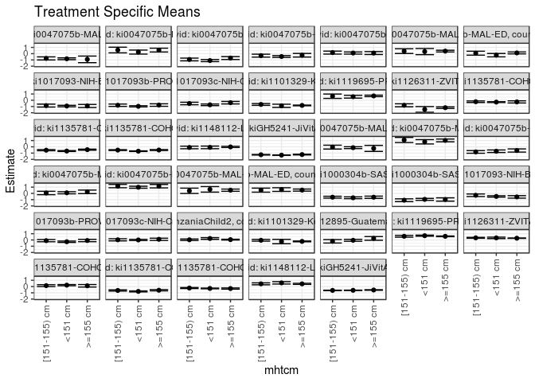

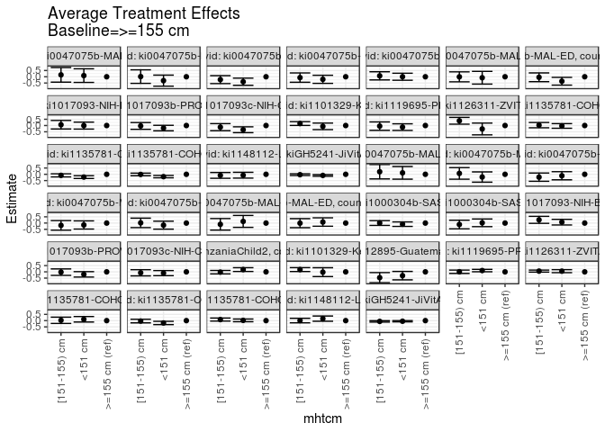

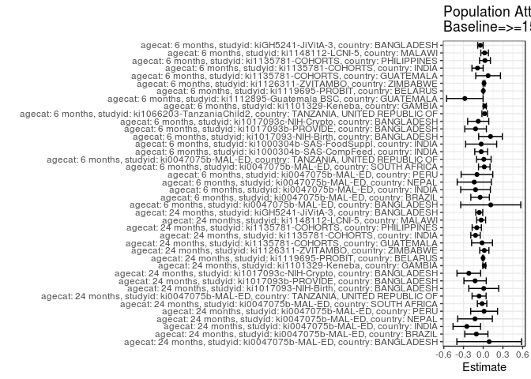

## Results Table

### Parameter: TSM

| agecat | studyid | country | intervention_level | baseline_level | estimate | ci_lower | ci_upper |
| --- | --- | --- | --- | --- | --- | --- | --- |
| 6 months | ki0047075b-MAL-ED | BANGLADESH | >=155 cm | NA | -0.2525383 | -0.7365311 | 0.2314545 |
| 6 months | ki0047075b-MAL-ED | BANGLADESH | <151 cm | NA | -0.1355172 | -0.2827155 | 0.0116811 |
| 6 months | ki0047075b-MAL-ED | BANGLADESH | [151-155) cm | NA | -0.0477906 | -0.3556838 | 0.2601026 |
| 6 months | ki0047075b-MAL-ED | BRAZIL | >=155 cm | NA | 1.0193449 | 0.7983455 | 1.2403444 |
| 6 months | ki0047075b-MAL-ED | BRAZIL | <151 cm | NA | 0.8009546 | 0.4540828 | 1.1478265 |
| 6 months | ki0047075b-MAL-ED | BRAZIL | [151-155) cm | NA | 1.0915528 | 0.6860120 | 1.4970936 |
| 6 months | ki0047075b-MAL-ED | INDIA | >=155 cm | NA | -0.5867392 | -0.8398745 | -0.3336040 |
| 6 months | ki0047075b-MAL-ED | INDIA | <151 cm | NA | -0.7035473 | -0.9045286 | -0.5025660 |
| 6 months | ki0047075b-MAL-ED | INDIA | [151-155) cm | NA | -0.8151260 | -1.0265310 | -0.6037210 |
| 6 months | ki0047075b-MAL-ED | NEPAL | >=155 cm | NA | 0.2466839 | -0.0355356 | 0.5289034 |
| 6 months | ki0047075b-MAL-ED | NEPAL | <151 cm | NA | 0.0956439 | -0.0738369 | 0.2651247 |
| 6 months | ki0047075b-MAL-ED | NEPAL | [151-155) cm | NA | 0.0624394 | -0.2086951 | 0.3335739 |
| 6 months | ki0047075b-MAL-ED | PERU | >=155 cm | NA | 1.1499497 | 0.8767834 | 1.4231160 |
| 6 months | ki0047075b-MAL-ED | PERU | <151 cm | NA | 0.9823597 | 0.8215522 | 1.1431671 |
| 6 months | ki0047075b-MAL-ED | PERU | [151-155) cm | NA | 1.1658386 | 0.9053335 | 1.4263438 |
| 6 months | ki0047075b-MAL-ED | SOUTH AFRICA | >=155 cm | NA | 0.5128610 | 0.3337033 | 0.6920187 |
| 6 months | ki0047075b-MAL-ED | SOUTH AFRICA | <151 cm | NA | 0.6461995 | 0.2047359 | 1.0876631 |
| 6 months | ki0047075b-MAL-ED | SOUTH AFRICA | [151-155) cm | NA | 0.4129522 | -0.0117404 | 0.8376448 |
| 6 months | ki0047075b-MAL-ED | TANZANIA, UNITED REPUBLIC OF | >=155 cm | NA | 0.5268187 | 0.3593342 | 0.6943033 |
| 6 months | ki0047075b-MAL-ED | TANZANIA, UNITED REPUBLIC OF | <151 cm | NA | 0.6090419 | 0.3178186 | 0.9002652 |
| 6 months | ki0047075b-MAL-ED | TANZANIA, UNITED REPUBLIC OF | [151-155) cm | NA | 0.5191404 | 0.1985018 | 0.8397791 |
| 6 months | ki1000304b-SAS-CompFeed | INDIA | >=155 cm | NA | -0.6117668 | -0.7878370 | -0.4356967 |
| 6 months | ki1000304b-SAS-CompFeed | INDIA | <151 cm | NA | -0.6996750 | -0.8438555 | -0.5554945 |
| 6 months | ki1000304b-SAS-CompFeed | INDIA | [151-155) cm | NA | -0.6081125 | -0.7584674 | -0.4577577 |
| 6 months | ki1000304b-SAS-FoodSuppl | INDIA | >=155 cm | NA | -0.9743453 | -1.2366037 | -0.7120868 |
| 6 months | ki1000304b-SAS-FoodSuppl | INDIA | <151 cm | NA | -0.9545721 | -1.1143171 | -0.7948272 |
| 6 months | ki1000304b-SAS-FoodSuppl | INDIA | [151-155) cm | NA | -1.0885419 | -1.3113301 | -0.8657538 |
| 6 months | ki1017093-NIH-Birth | BANGLADESH | >=155 cm | NA | -0.5587855 | -0.7547306 | -0.3628404 |
| 6 months | ki1017093-NIH-Birth | BANGLADESH | <151 cm | NA | -0.4842080 | -0.5988675 | -0.3695485 |
| 6 months | ki1017093-NIH-Birth | BANGLADESH | [151-155) cm | NA | -0.3011396 | -0.5046282 | -0.0976510 |

[output cut: 90 more lines]

### Parameter: E(Y)

| agecat | studyid | country | intervention_level | baseline_level | estimate | ci_lower | ci_upper |
| --- | --- | --- | --- | --- | --- | --- | --- |
| 6 months | ki0047075b-MAL-ED | BANGLADESH | NA | NA | -0.1376763 | -0.2664642 | -0.0088885 |
| 6 months | ki0047075b-MAL-ED | BRAZIL | NA | NA | 0.9720774 | 0.8078144 | 1.1363403 |
| 6 months | ki0047075b-MAL-ED | INDIA | NA | NA | -0.7034149 | -0.8300527 | -0.5767771 |
| 6 months | ki0047075b-MAL-ED | NEPAL | NA | NA | 0.1104308 | -0.0208643 | 0.2417259 |
| 6 months | ki0047075b-MAL-ED | PERU | NA | NA | 1.0548591 | 0.9328922 | 1.1768259 |
| 6 months | ki0047075b-MAL-ED | SOUTH AFRICA | NA | NA | 0.5291499 | 0.3751396 | 0.6831602 |
| 6 months | ki0047075b-MAL-ED | TANZANIA, UNITED REPUBLIC OF | NA | NA | 0.5362213 | 0.4049390 | 0.6675036 |
| 6 months | ki1000304b-SAS-CompFeed | INDIA | NA | NA | -0.6426305 | -0.7702214 | -0.5150396 |
| 6 months | ki1000304b-SAS-FoodSuppl | INDIA | NA | NA | -1.0053826 | -1.1208084 | -0.8899568 |
| 6 months | ki1017093-NIH-Birth | BANGLADESH | NA | NA | -0.4474038 | -0.5378167 | -0.3569909 |
| 6 months | ki1017093b-PROVIDE | BANGLADESH | NA | NA | -0.1987071 | -0.2815473 | -0.1158669 |
| 6 months | ki1017093c-NIH-Crypto | BANGLADESH | NA | NA | 0.0297622 | -0.0491685 | 0.1086930 |
| 6 months | ki1066203-TanzaniaChild2 | TANZANIA, UNITED REPUBLIC OF | NA | NA | 0.0787757 | 0.0256721 | 0.1318793 |
| 6 months | ki1101329-Keneba | GAMBIA | NA | NA | -0.2053991 | -0.2588843 | -0.1519138 |
| 6 months | ki1112895-Guatemala BSC | GUATEMALA | NA | NA | -0.0255916 | -0.1507513 | 0.0995680 |
| 6 months | ki1119695-PROBIT | BELARUS | NA | NA | 0.5827947 | 0.5245418 | 0.6410476 |
| 6 months | ki1126311-ZVITAMBO | ZIMBABWE | NA | NA | 0.2948466 | 0.2673139 | 0.3223793 |
| 6 months | ki1135781-COHORTS | GUATEMALA | NA | NA | 0.1926004 | 0.1207018 | 0.2644990 |
| 6 months | ki1135781-COHORTS | INDIA | NA | NA | -0.6768114 | -0.7301317 | -0.6234912 |
| 6 months | ki1135781-COHORTS | PHILIPPINES | NA | NA | -0.2938433 | -0.3352064 | -0.2524802 |
| 6 months | ki1148112-LCNI-5 | MALAWI | NA | NA | 0.4515550 | 0.3802638 | 0.5228463 |
| 6 months | kiGH5241-JiVitA-3 | BANGLADESH | NA | NA | -0.5932195 | -0.6127714 | -0.5736676 |
| 24 months | ki0047075b-MAL-ED | BANGLADESH | NA | NA | -0.8192925 | -0.9412667 | -0.6973182 |
| 24 months | ki0047075b-MAL-ED | BRAZIL | NA | NA | 0.4626233 | 0.2567495 | 0.6684971 |
| 24 months | ki0047075b-MAL-ED | INDIA | NA | NA | -0.9519248 | -1.0678488 | -0.8360007 |
| 24 months | ki0047075b-MAL-ED | NEPAL | NA | NA | -0.3749123 | -0.4886073 | -0.2612173 |
| 24 months | ki0047075b-MAL-ED | PERU | NA | NA | 0.1111982 | -0.0118399 | 0.2342362 |
| 24 months | ki0047075b-MAL-ED | SOUTH AFRICA | NA | NA | 0.3916417 | 0.2704414 | 0.5128421 |
| 24 months | ki0047075b-MAL-ED | TANZANIA, UNITED REPUBLIC OF | NA | NA | 0.0547975 | -0.0703378 | 0.1799328 |
| 24 months | ki1017093-NIH-Birth | BANGLADESH | NA | NA | -0.9115790 | -1.0095022 | -0.8136559 |
| 24 months | ki1017093b-PROVIDE | BANGLADESH | NA | NA | -0.8914360 | -0.9741797 | -0.8086923 |
| 24 months | ki1017093c-NIH-Crypto | BANGLADESH | NA | NA | -0.6103502 | -0.7050157 | -0.5156847 |
| 24 months | ki1101329-Keneba | GAMBIA | NA | NA | -0.8101717 | -0.8592463 | -0.7610970 |
| 24 months | ki1119695-PROBIT | BELARUS | NA | NA | 0.6880695 | 0.5737062 | 0.8024328 |
| 24 months | ki1126311-ZVITAMBO | ZIMBABWE | NA | NA | -1.1712534 | -1.2800940 | -1.0624128 |
| 24 months | ki1135781-COHORTS | GUATEMALA | NA | NA | -0.2844036 | -0.3405555 | -0.2282517 |
| 24 months | ki1135781-COHORTS | INDIA | NA | NA | -0.5719523 | -0.6185009 | -0.5254037 |
| 24 months | ki1135781-COHORTS | PHILIPPINES | NA | NA | -0.6099592 | -0.6467541 | -0.5731643 |
| 24 months | ki1148112-LCNI-5 | MALAWI | NA | NA | -0.0468717 | -0.1290135 | 0.0352701 |
| 24 months | kiGH5241-JiVitA-3 | BANGLADESH | NA | NA | -1.2970642 | -1.3203662 | -1.2737621 |

### Parameter: ATE

| agecat | studyid | country | intervention_level | baseline_level | estimate | ci_lower | ci_upper |
| --- | --- | --- | --- | --- | --- | --- | --- |
| 6 months | ki0047075b-MAL-ED | BANGLADESH | >=155 cm | >=155 cm | 0.0000000 | 0.0000000 | 0.0000000 |
| 6 months | ki0047075b-MAL-ED | BANGLADESH | <151 cm | >=155 cm | 0.1170211 | -0.3887820 | 0.6228241 |
| 6 months | ki0047075b-MAL-ED | BANGLADESH | [151-155) cm | >=155 cm | 0.2047477 | -0.3692067 | 0.7787020 |
| 6 months | ki0047075b-MAL-ED | BRAZIL | >=155 cm | >=155 cm | 0.0000000 | 0.0000000 | 0.0000000 |
| 6 months | ki0047075b-MAL-ED | BRAZIL | <151 cm | >=155 cm | -0.2183903 | -0.6289383 | 0.1921577 |
| 6 months | ki0047075b-MAL-ED | BRAZIL | [151-155) cm | >=155 cm | 0.0722078 | -0.3897790 | 0.5341946 |
| 6 months | ki0047075b-MAL-ED | INDIA | >=155 cm | >=155 cm | 0.0000000 | 0.0000000 | 0.0000000 |
| 6 months | ki0047075b-MAL-ED | INDIA | <151 cm | >=155 cm | -0.1168080 | -0.4407417 | 0.2071257 |
| 6 months | ki0047075b-MAL-ED | INDIA | [151-155) cm | >=155 cm | -0.2283867 | -0.5588977 | 0.1021242 |
| 6 months | ki0047075b-MAL-ED | NEPAL | >=155 cm | >=155 cm | 0.0000000 | 0.0000000 | 0.0000000 |
| 6 months | ki0047075b-MAL-ED | NEPAL | <151 cm | >=155 cm | -0.1510400 | -0.4775910 | 0.1755110 |
| 6 months | ki0047075b-MAL-ED | NEPAL | [151-155) cm | >=155 cm | -0.1842446 | -0.5677417 | 0.1992526 |
| 6 months | ki0047075b-MAL-ED | PERU | >=155 cm | >=155 cm | 0.0000000 | 0.0000000 | 0.0000000 |
| 6 months | ki0047075b-MAL-ED | PERU | <151 cm | >=155 cm | -0.1675901 | -0.4843009 | 0.1491207 |
| 6 months | ki0047075b-MAL-ED | PERU | [151-155) cm | >=155 cm | 0.0158889 | -0.3615174 | 0.3932952 |
| 6 months | ki0047075b-MAL-ED | SOUTH AFRICA | >=155 cm | >=155 cm | 0.0000000 | 0.0000000 | 0.0000000 |
| 6 months | ki0047075b-MAL-ED | SOUTH AFRICA | <151 cm | >=155 cm | 0.1333385 | -0.3438164 | 0.6104934 |
| 6 months | ki0047075b-MAL-ED | SOUTH AFRICA | [151-155) cm | >=155 cm | -0.0999088 | -0.5613425 | 0.3615248 |
| 6 months | ki0047075b-MAL-ED | TANZANIA, UNITED REPUBLIC OF | >=155 cm | >=155 cm | 0.0000000 | 0.0000000 | 0.0000000 |
| 6 months | ki0047075b-MAL-ED | TANZANIA, UNITED REPUBLIC OF | <151 cm | >=155 cm | 0.0822231 | -0.2538460 | 0.4182922 |
| 6 months | ki0047075b-MAL-ED | TANZANIA, UNITED REPUBLIC OF | [151-155) cm | >=155 cm | -0.0076783 | -0.3701624 | 0.3548058 |
| 6 months | ki1000304b-SAS-CompFeed | INDIA | >=155 cm | >=155 cm | 0.0000000 | 0.0000000 | 0.0000000 |
| 6 months | ki1000304b-SAS-CompFeed | INDIA | <151 cm | >=155 cm | -0.0879082 | -0.2682236 | 0.0924072 |
| 6 months | ki1000304b-SAS-CompFeed | INDIA | [151-155) cm | >=155 cm | 0.0036543 | -0.1855761 | 0.1928847 |
| 6 months | ki1000304b-SAS-FoodSuppl | INDIA | >=155 cm | >=155 cm | 0.0000000 | 0.0000000 | 0.0000000 |
| 6 months | ki1000304b-SAS-FoodSuppl | INDIA | <151 cm | >=155 cm | 0.0197731 | -0.2877060 | 0.3272522 |
| 6 months | ki1000304b-SAS-FoodSuppl | INDIA | [151-155) cm | >=155 cm | -0.1141967 | -0.4579114 | 0.2295181 |
| 6 months | ki1017093-NIH-Birth | BANGLADESH | >=155 cm | >=155 cm | 0.0000000 | 0.0000000 | 0.0000000 |
| 6 months | ki1017093-NIH-Birth | BANGLADESH | <151 cm | >=155 cm | 0.0745775 | -0.1511827 | 0.3003377 |
| 6 months | ki1017093-NIH-Birth | BANGLADESH | [151-155) cm | >=155 cm | 0.2576459 | -0.0236941 | 0.5389860 |

[output cut: 90 more lines]

### Parameter: PAR

| agecat | studyid | country | intervention_level | baseline_level | estimate | ci_lower | ci_upper |
| --- | --- | --- | --- | --- | --- | --- | --- |
| 6 months | ki0047075b-MAL-ED | BANGLADESH | >=155 cm | NA | 0.1148619 | -0.3422209 | 0.5719448 |
| 6 months | ki0047075b-MAL-ED | BRAZIL | >=155 cm | NA | -0.0472676 | -0.1885174 | 0.0939822 |
| 6 months | ki0047075b-MAL-ED | INDIA | >=155 cm | NA | -0.1166756 | -0.3426089 | 0.1092576 |
| 6 months | ki0047075b-MAL-ED | NEPAL | >=155 cm | NA | -0.1362531 | -0.3960303 | 0.1235240 |
| 6 months | ki0047075b-MAL-ED | PERU | >=155 cm | NA | -0.0950906 | -0.3360719 | 0.1458906 |
| 6 months | ki0047075b-MAL-ED | SOUTH AFRICA | >=155 cm | NA | 0.0162889 | -0.0713742 | 0.1039520 |
| 6 months | ki0047075b-MAL-ED | TANZANIA, UNITED REPUBLIC OF | >=155 cm | NA | 0.0094026 | -0.1014131 | 0.1202183 |
| 6 months | ki1000304b-SAS-CompFeed | INDIA | >=155 cm | NA | -0.0308637 | -0.1284069 | 0.0666795 |
| 6 months | ki1000304b-SAS-FoodSuppl | INDIA | >=155 cm | NA | -0.0310373 | -0.2670079 | 0.2049332 |
| 6 months | ki1017093-NIH-Birth | BANGLADESH | >=155 cm | NA | 0.1113817 | -0.0689855 | 0.2917489 |
| 6 months | ki1017093b-PROVIDE | BANGLADESH | >=155 cm | NA | -0.1160232 | -0.2805584 | 0.0485120 |
| 6 months | ki1017093c-NIH-Crypto | BANGLADESH | >=155 cm | NA | -0.0759141 | -0.2364608 | 0.0846327 |
| 6 months | ki1066203-TanzaniaChild2 | TANZANIA, UNITED REPUBLIC OF | >=155 cm | NA | 0.0222879 | -0.0194945 | 0.0640702 |
| 6 months | ki1101329-Keneba | GAMBIA | >=155 cm | NA | 0.0234602 | -0.0007755 | 0.0476960 |
| 6 months | ki1112895-Guatemala BSC | GUATEMALA | >=155 cm | NA | -0.2791082 | -0.5562188 | -0.0019975 |
| 6 months | ki1119695-PROBIT | BELARUS | >=155 cm | NA | 0.0015779 | -0.0027276 | 0.0058834 |
| 6 months | ki1126311-ZVITAMBO | ZIMBABWE | >=155 cm | NA | 0.0125650 | -0.0016627 | 0.0267928 |
| 6 months | ki1135781-COHORTS | GUATEMALA | >=155 cm | NA | 0.0747235 | -0.1132586 | 0.2627057 |
| 6 months | ki1135781-COHORTS | INDIA | >=155 cm | NA | -0.0860635 | -0.1713715 | -0.0007554 |
| 6 months | ki1135781-COHORTS | PHILIPPINES | >=155 cm | NA | 0.0272695 | -0.0554010 | 0.1099400 |
| 6 months | ki1148112-LCNI-5 | MALAWI | >=155 cm | NA | 0.0216478 | -0.0360940 | 0.0793895 |
| 6 months | kiGH5241-JiVitA-3 | BANGLADESH | >=155 cm | NA | -0.0421014 | -0.0832512 | -0.0009515 |
| 24 months | ki0047075b-MAL-ED | BANGLADESH | >=155 cm | NA | 0.0908667 | -0.4009791 | 0.5827124 |
| 24 months | ki0047075b-MAL-ED | BRAZIL | >=155 cm | NA | -0.1044082 | -0.2807148 | 0.0718984 |
| 24 months | ki0047075b-MAL-ED | INDIA | >=155 cm | NA | -0.2499912 | -0.4592512 | -0.0407311 |
| 24 months | ki0047075b-MAL-ED | NEPAL | >=155 cm | NA | -0.1246477 | -0.3881728 | 0.1388773 |
| 24 months | ki0047075b-MAL-ED | PERU | >=155 cm | NA | 0.0140973 | -0.1903159 | 0.2185104 |
| 24 months | ki0047075b-MAL-ED | SOUTH AFRICA | >=155 cm | NA | -0.0169092 | -0.0885538 | 0.0547354 |
| 24 months | ki0047075b-MAL-ED | TANZANIA, UNITED REPUBLIC OF | >=155 cm | NA | -0.0627610 | -0.1695950 | 0.0440729 |
| 24 months | ki1017093-NIH-Birth | BANGLADESH | >=155 cm | NA | 0.0081061 | -0.2192358 | 0.2354480 |
| 24 months | ki1017093b-PROVIDE | BANGLADESH | >=155 cm | NA | -0.1236518 | -0.2933849 | 0.0460813 |
| 24 months | ki1017093c-NIH-Crypto | BANGLADESH | >=155 cm | NA | -0.2189429 | -0.3989288 | -0.0389570 |
| 24 months | ki1101329-Keneba | GAMBIA | >=155 cm | NA | 0.0161634 | -0.0058156 | 0.0381423 |
| 24 months | ki1119695-PROBIT | BELARUS | >=155 cm | NA | -0.0018700 | -0.0118836 | 0.0081437 |
| 24 months | ki1126311-ZVITAMBO | ZIMBABWE | >=155 cm | NA | 0.0171060 | -0.0531676 | 0.0873796 |
| 24 months | ki1135781-COHORTS | GUATEMALA | >=155 cm | NA | -0.0176242 | -0.1761448 | 0.1408964 |
| 24 months | ki1135781-COHORTS | INDIA | >=155 cm | NA | -0.1170901 | -0.1886539 | -0.0455262 |
| 24 months | ki1135781-COHORTS | PHILIPPINES | >=155 cm | NA | -0.0982446 | -0.1684317 | -0.0280575 |
| 24 months | ki1148112-LCNI-5 | MALAWI | >=155 cm | NA | -0.0312162 | -0.0991652 | 0.0367328 |
| 24 months | kiGH5241-JiVitA-3 | BANGLADESH | >=155 cm | NA | -0.0605277 | -0.1135638 | -0.0074917 |